# Act Report

## By: James Case

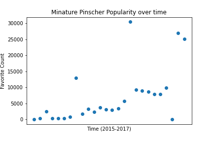

```python
from PIL import Image
Image.open('popvtime.png')
```

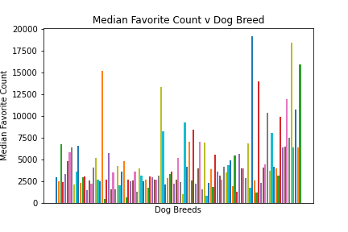

```python
Image.open('meddog.png')
```

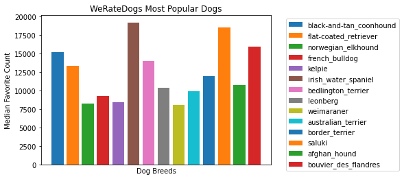

```python
from PIL import Image
Image.open('BarChart.png')
```

First, I note that the WeRateDogs twitter page grew drastically from 2015-2017. This can be seen in the 'Minature Pinscher Popularity over time' graph where most data appears left-skewed indicating that dogs were less popular in 2015 than 2017. This is a common reoccurence in the data. However, the real reason the data is most likely left-skewed is that the WeRateDogs twitter account grew in popularity and thus favorites. This would lead to an unfair advantage to tweets placed in 2017 as there would be more people favoriting. To counteract this the median like values for each breed was used in analysis.

Next, I noticed most dog breeds had a median favorite retweet of less than 7500 votes. This can be seen in the 'Median Favorite Count v Dog Breed' graph. This could be indicative that most dogs are equal in favoritability and only those that really stand out get more votes. It is difficult to say but the time of the tweets during the week and during the day may affect likes as well. This could be further explored in the future to determine the best time to tweet dog pictures to get maximum likes.